# SDMs: daily exercises

### Exercise 3: Working with different raster resolutions

The first time you download WorldClim data, you can run the code below. Thereafter, you can just read it in from your working directory without having to re-download it each time.

For interest:

- 2.5 arc-minutes = ~ 4.6 km grid cells
- 10 arc-minutes = ~ 18.5 km grid cells

If downloading for the first time, run this:

```r
pred_clim_2.5 = geodata::worldclim_global(
    var = "bio",
    res = 2.5,      # Minute degree resolution of raster layers
    path = here::here("./data/environmental_layers/current/"),
    version = "2.1"
)

pred_clim_10 = geodata::worldclim_global(
    var = "bio",
    res = 10,      # Minute degree resolution of raster layers
    path = here::here("./data/environmental_layers/current/"),
    version = "2.1"
)
```

If already downloaded, read in:

```r
# read in 2.5 res
pred_clim_2.5 = terra::rast( list.files(
  here::here("data/environmental_layers/current/wc2.1_2.5m/") ,
  full.names = TRUE,
  pattern = '.tif'
))

# read in 10 res
pred_clim_10 = terra::rast( list.files(
  here::here("data/environmental_layers/current/wc2.1_10m/") ,
  full.names = TRUE,
  pattern = '.tif'
))
```

Make sure the Coordinate Reference System (CRS) is set:

```r
#pred_clim_2.5
#pred_clim_10

# set the CRS (coordinate reference system) projection for the current climate layers
terra::crs(pred_clim_2.5) = "epsg:4326"
terra::crs(pred_clim_2.5, describe = T)
```

```
##     name authority code  area             extent
## 1 WGS 84      EPSG 4326 World -180, 180, 90, -90
```

```r
terra::crs(pred_clim_10) = "epsg:4326"
terra::crs(pred_clim_10, describe = T)
```

```
##     name authority code  area             extent
## 1 WGS 84      EPSG 4326 World -180, 180, 90, -90
```

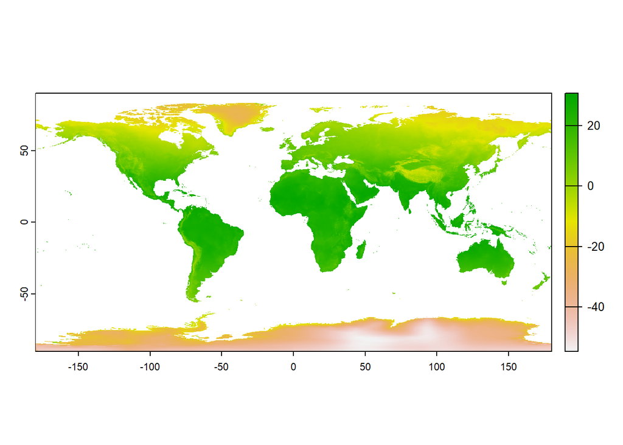

```r
# plot the first variable, annual mean temperature:
terra::plot(pred_clim_2.5$wc2.1_2.5m_bio_1)
```

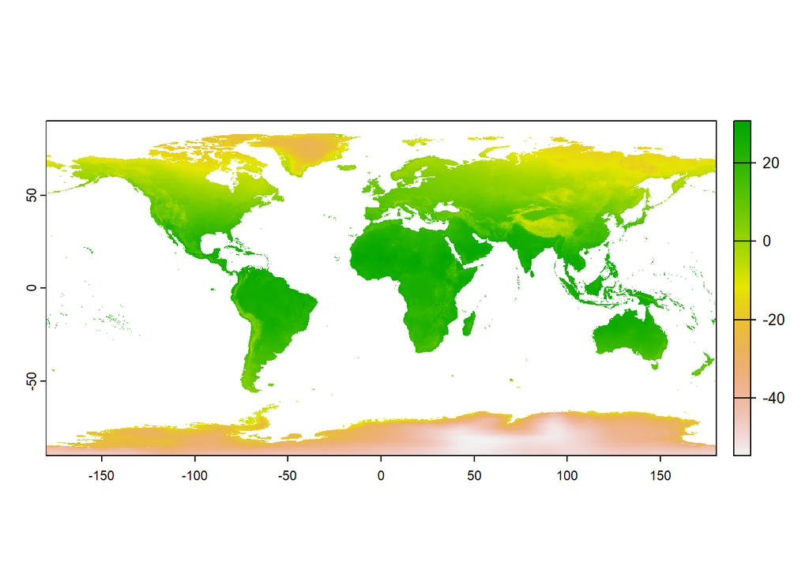

```r
terra::plot(pred_clim_10$wc2.1_10m_bio_1)
```

Let’s have a look at the annual average temperature (bio1) for just South Africa:

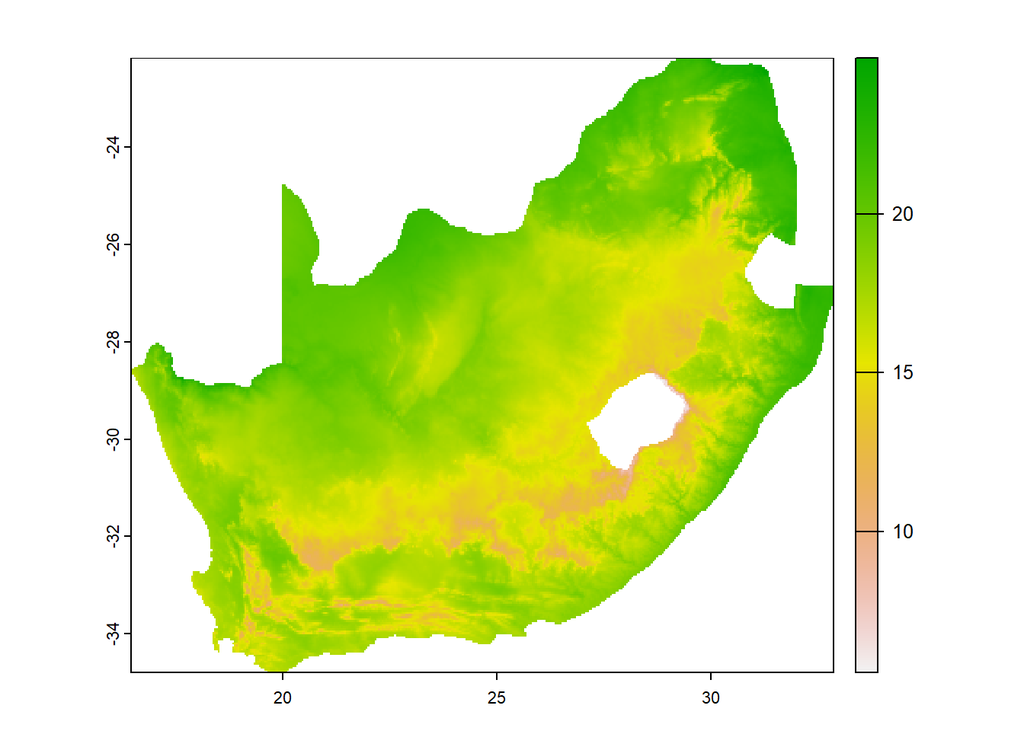

```r
# get a raster map of South Africa
southafrica_ext = rnaturalearth::ne_countries(scale = "medium", returnclass = "sf") %>%
                  dplyr::filter(name %in% c("South Africa"))

# convert the SA raster map into a SpatVector object
southafrica_vect = terra::vect(southafrica_ext)
# define the extent of South Africa, excluding Marion Island
country_ext = ext(16, 33, -35, -22)
# crop the SA SpatVector accordingly
southafrica_vect = terra::crop(southafrica_vect, country_ext)

# crop our WorldClim (2.5 res) bio1 layer to only SA
sa_2.5 = terra::crop(pred_clim_2.5$wc2.1_2.5m_bio_1, southafrica_vect)
# apply a mask so that SA is shown exclusively - not any bordering areas
sa_2.5 = terra::mask(sa_2.5, southafrica_vect)
terra::plot(sa_2.5)
```

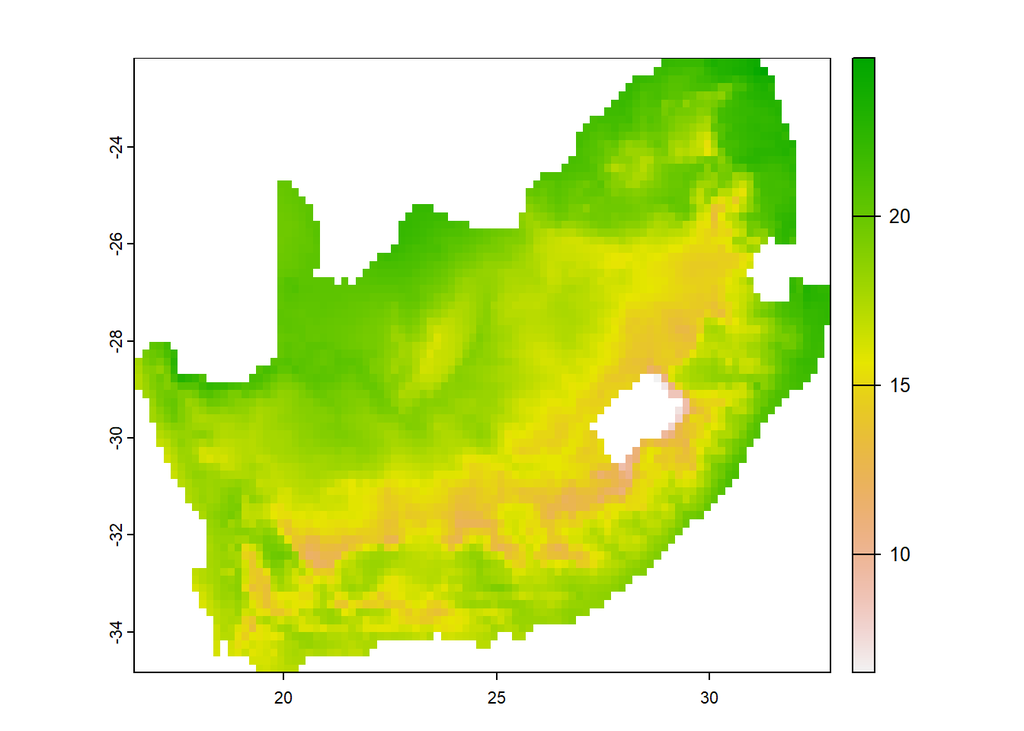

```r
# apply the same cropping and masking to the WorldClim raster at 10 arc-min resolution
sa_10 = terra::crop(pred_clim_10$wc2.1_10m_bio_1, southafrica_vect)
sa_10 = terra::mask(sa_10, southafrica_vect)
terra::plot(sa_10)
```

Let’s zoom in to just the Eastern Cape, and look at the resolutions. Each grid cell has an associated value. Here, we’ll keep looking at temperature:

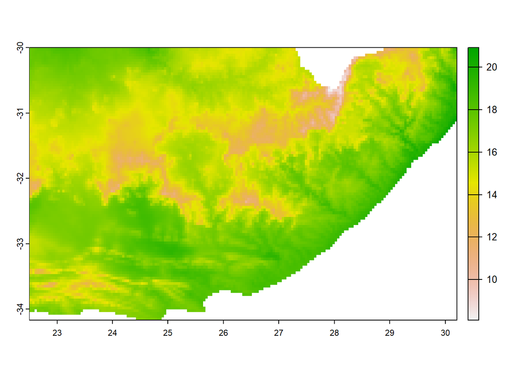

```r
# crop the extent to the Eastern Cape (eyeball this from the SA map)
EC_ext = ext(22.5, 30.2, -34.2, -30.0)

EC_vect = terra::crop(southafrica_vect, EC_ext)

EC_2.5 = terra::crop(pred_clim_2.5$wc2.1_2.5m_bio_1, EC_vect)
EC_2.5 = terra::mask(EC_2.5, EC_vect)
terra::plot(EC_2.5)
```

```r
# how many cells do we have in this raster?
terra::ncell(EC_2.5)
```

```
## [1] 18500
```

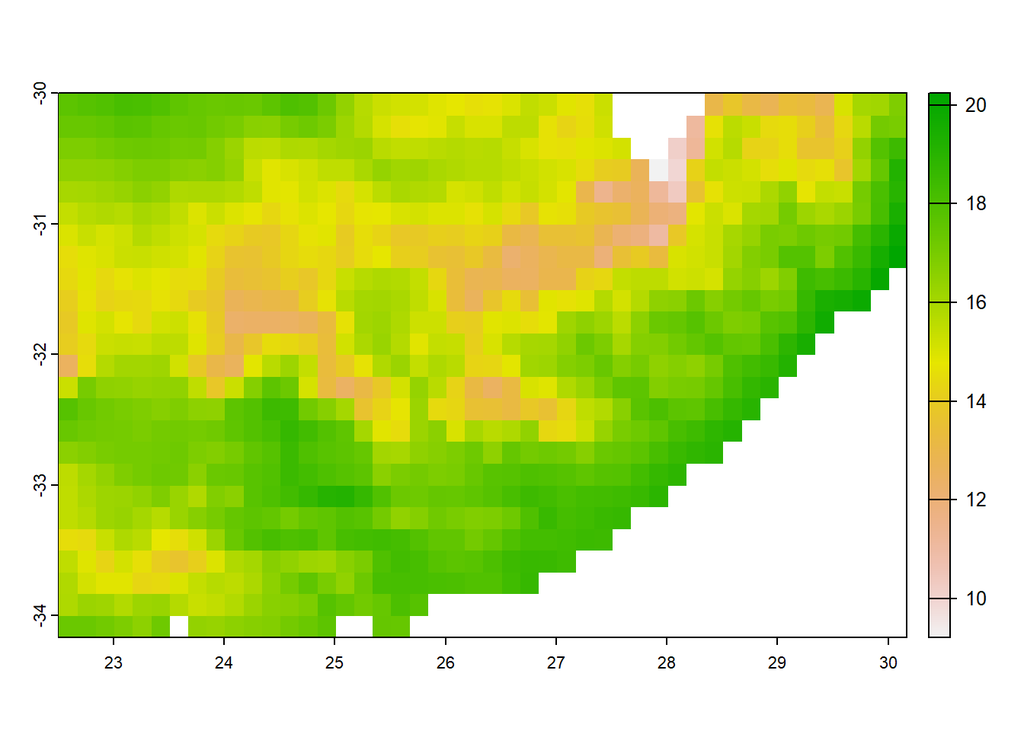

```r
EC_10 = terra::crop(pred_clim_10$wc2.1_10m_bio_1, EC_vect)
EC_10 = terra::mask(EC_10, EC_vect)
terra::plot(EC_10)
```

```r
# check cell number again here
terra::ncell(EC_10)
```

```
## [1] 1150
```

The EC map at 2.5 arc-minutes has ~16X more grid cells (18500/1150) than the map at the 10 arc-minute resolution. This means that you will extract 16X more temperature data points from the higher resolution map than the lower one!

To take a closer look at how this might affect our data, let’s select 1000 random GPS points from South Africa. Then, we will extract the temperature values at each GPS point on the high and low resolution map. We can then compare our data for the same location, but at those two different resolutions.

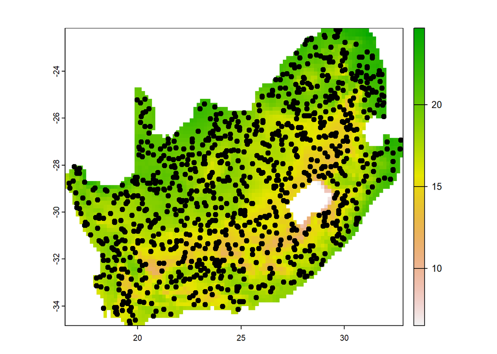

```r
# setting a seed makes this process repeatable, if you re-run this again
set.seed(2023)

# randomly select 1000 points, and store the temperature at each
randomSA.points = terra::spatSample(
    x = sa_2.5,         # Raster area to sample points from
    size = 1000,         # How many points do we want?
    method = "random",  # Random points
    replace = FALSE,    # Sample without replacement
    na.rm = TRUE,       # Remove points that have NA climate data
    as.df = TRUE,       # Return points as data.frame object
    xy = TRUE,          # Return lat/lon values for each point
    values = FALSE  # just give the lat and lon coordinates, not the cell values
  ) %>%
  as.data.frame() %>%
dplyr::rename(lon = x, lat = y)

terra::plot(sa_10)
terra::points(randomSA.points$lon, randomSA.points$lat, bg = "black", pch = 21)
```

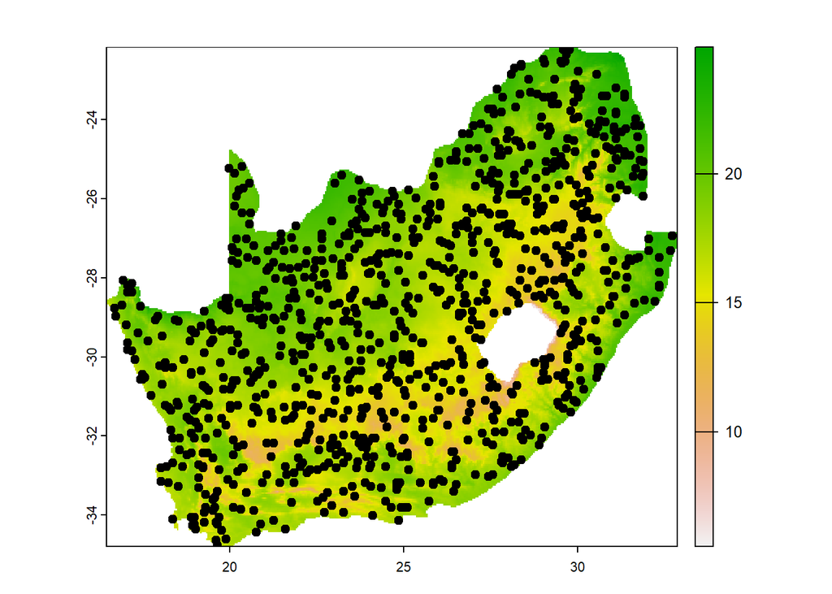

```r
terra::plot(sa_2.5)
terra::points(randomSA.points$lon, randomSA.points$lat, bg = "black", pch = 21)
```

Let’s extract the temperature values at each GPS coordinate on the 2.5 and 10 maps:

```r
# extract the temperature data at the GPS points
clim_2.5 = base::data.frame( raster::extract(sa_2.5,
                cbind(randomSA.points$lon, randomSA.points$lat)) )

# add the lat and lon columns to the data
clim_2.5 = cbind(randomSA.points, clim_2.5)

# extract the temperature data at the GPS points
clim_10 = base::data.frame( raster::extract(sa_10,
                cbind(randomSA.points$lon, randomSA.points$lat)) )

# add the lat and lon columns to the data
clim_10 = cbind(randomSA.points, clim_10)
```

We now have two sets of temperature data for South Africa, extracted at 1000 randomly-generated GPS points for: (1) the map at 2.5 arc-min resolution, and (2) the map at 10 arc-min resolution.

🟢 **Your task is to compare these two data sets. You should:**

- Find the minimum and maximum temperature values for each set (you can use `summary()`)
- Run a quick t-test: is there a significant difference between the two temperature sets?
- Create a new column, `diff`, that contains the difference between the 10 and 2.5 arc-min values at each GPS point
- Code is provided to show you how you can visualise these differences using tiles that are coloured to indicate their magnitude; like a heatmap. Which areas of South Africa show more differences in temperature between the two resolutions?
- Create a point plot where you plot `res2.5` on the x-axis and `res10` on the y-axis. Add an `abline` to this plot using `geom_abline(slope = 1, intercept = 0, linetype = "dashed", color = "red")`. If the temperature values at each GPS coordinate across the two map resolutions are identical, we would expect the points to fall exactly on that straight (y = x) line. The distance away from the line therefore gives us an indication of the difference between the values
- What is the R-squared value here (run a linear model)?

```r
# bind the two datasets
clim_compare = cbind(clim_2.5, clim_10$wc2.1_10m_bio_1)
# rename columns for clarity
colnames(clim_compare) = c("lon", "lat", "res2.5", "res10")

head(clim_compare)
```

```
##        lon       lat   res2.5    res10
## 1 20.60417 -28.77083 20.32183 20.38588
## 2 23.89583 -27.60417 16.89717 16.92934
## 3 28.52083 -25.81250 16.69750 16.98459
## 4 32.35417 -28.18750 21.76783 21.79795
## 5 28.64583 -23.31250 20.80717 20.60656
## 6 30.97917 -25.22917 18.53350 18.53790
```

```r
# FIND MIN AND MAX TEMPERATURES HERE

# RUN A T-TEST HERE

# calculate the difference between res10 and res2.5
clim_compare$diff = # CALCULATE THE DIFFERENCE BETWEEN res10 AND res2.5

# remove NAs
clim_compare = clim_compare %>%
  na.omit(diff)

# round off the lat and lons to plot easily
clim_compare$lon_round = round(clim_compare$lon, 1)
clim_compare$lat_round = round(clim_compare$lat, 1)

ggplot(clim_compare, aes(x = lon_round, y = lat_round, fill = diff)) +
  geom_tile(color = "black", size = 0.1) +
  scale_fill_gradient2(low = "blue", mid = "white", high = "red",
                       breaks = seq(-2, 2, by = 1), limits = c(-2, 2) ) +
  coord_fixed() +
  theme_classic() +
  labs(title = "Difference Between 10 and 2.5 arc-min resolutions",
       x = "Longitude", y = "Latitude",
       fill = "res10 - res2.5")
```

Your tile plot should resemble this:

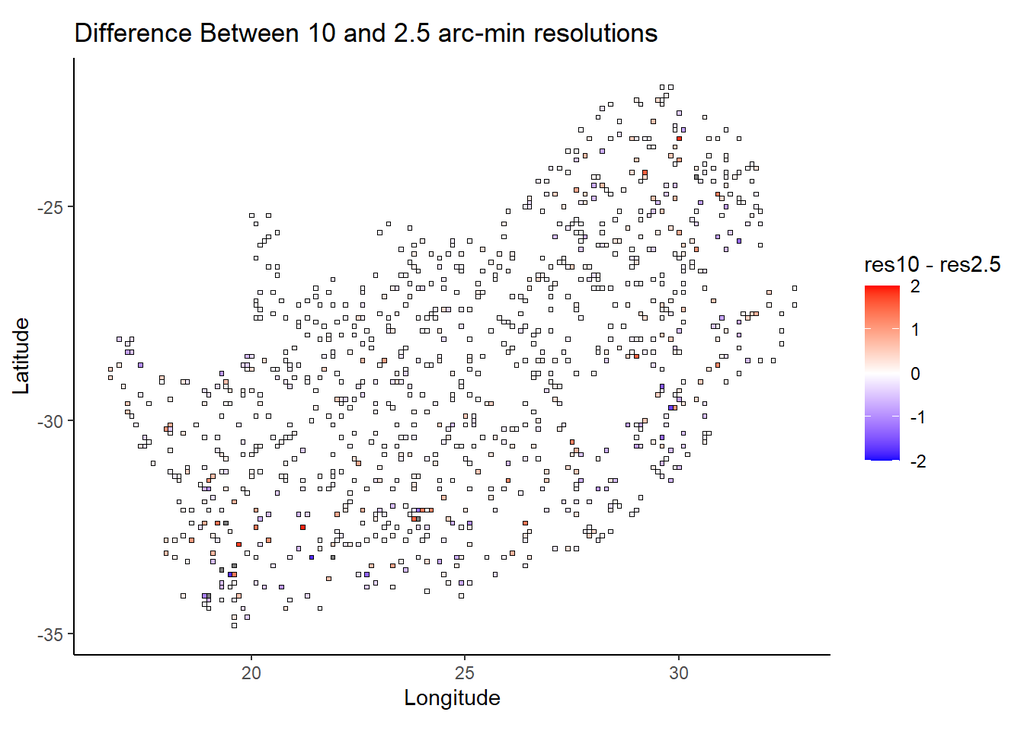

```r
# CREATE THE CORRELATION PLOT HERE SHOWING THE RELATIONSHIP BETWEEN res10 and res2.5

# RUN A LM HERE TO FIND THE R-SQUARED VALUE
```

You should get a correlation plot that looks something like this:

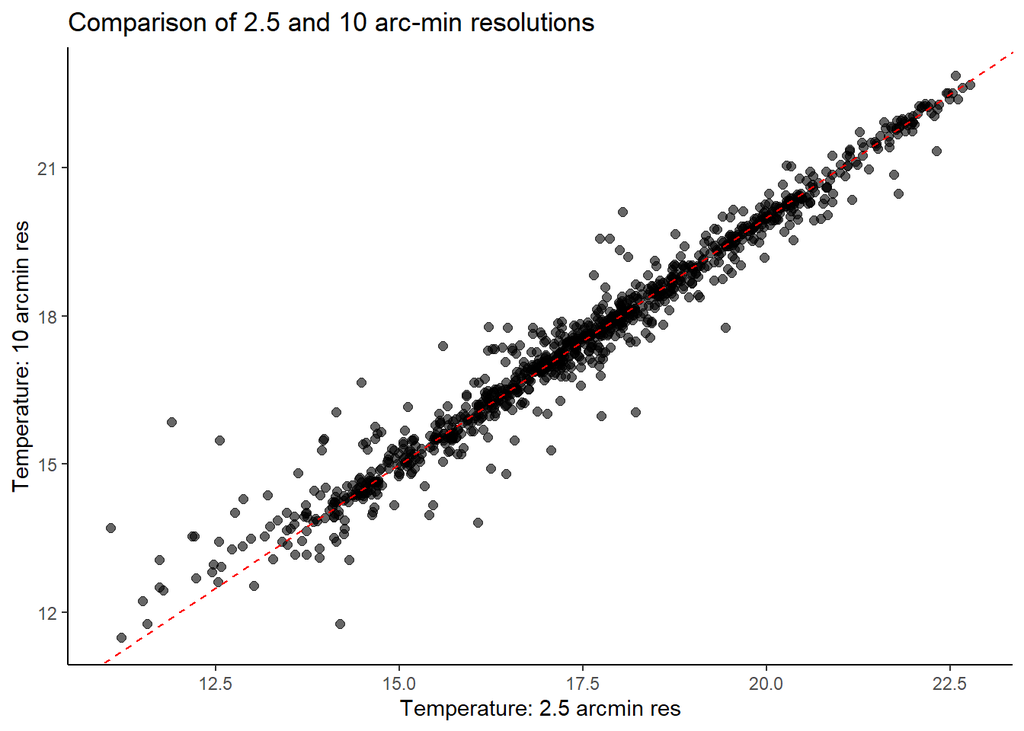

### Exercise 4: Compare climate variables between two regions

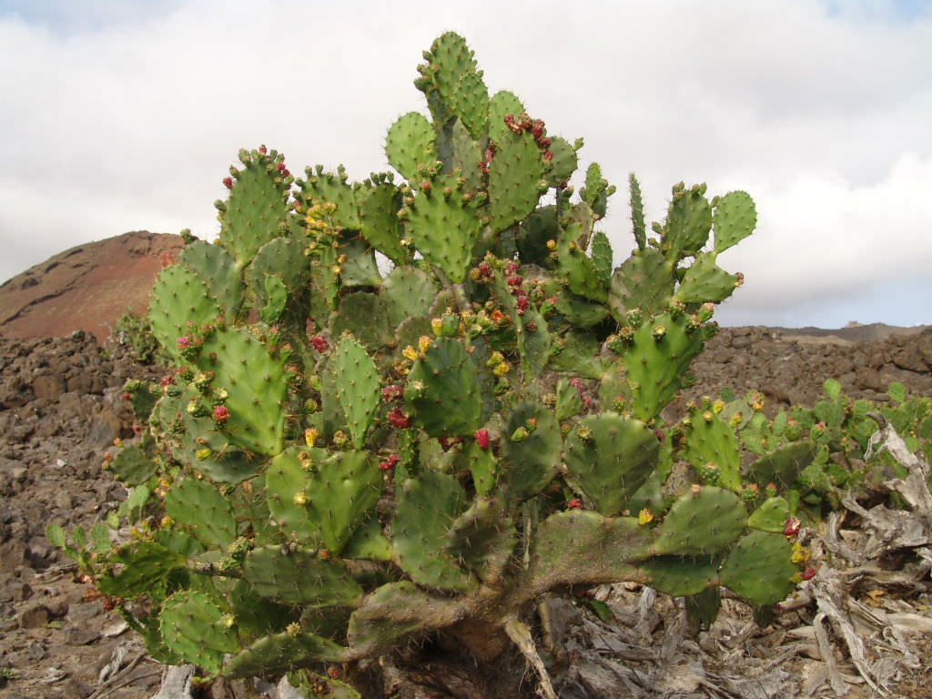

Here, we are going to look at a species of cactus, *Opuntia monacantha* (drooping prickly pear). This cactus is native to the Americas, and has become invasive in many parts of the world, including South Africa. In this exercise, we’ll compare the climate (specifically temperature and precipitation) between its native range in South America and a new area -> we’ll pick Cameroon.

🌰 In a nutshell, this exercise:

- Extracts temperature and precipitation data from the native range of the cactus in South America
- Extracts temperature and precipitation data from Cameroon (from each grid cell on the map of Cameroon)
- Compares the climate data between the two ranges -> is there a significant difference? How might this affect SDM transferability if the model was trained on South American points and projected onto Cameroon?

```r
o.mon = geodata::sp_occurrence(
  genus = "Opuntia",
  species = "monacantha",
  download = TRUE,
  geo = TRUE,
  removeZeros = TRUE
)

saveRDS(o.mon, "data/opuntia_monacantha.rds")
```

Read in our points, and plot on a world map:

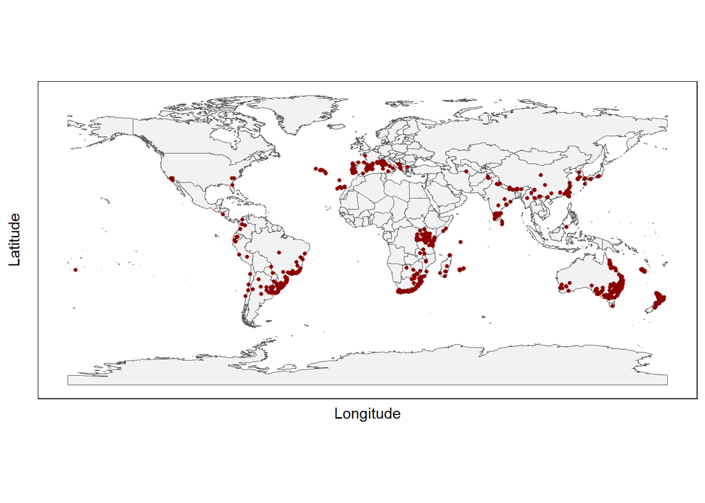

```r
o.mon = readRDS("data/opuntia_monacantha.rds")

world_map = rnaturalearth::ne_countries(
  scale = "medium",
  returnclass = "sf"
)

ggplot() +
  # Add raster layer of world map
  geom_sf(data = world_map, alpha = 0.5) +
  # Add GPS points
  geom_point(
    data = o.mon,
    size = 1, colour = "darkred",
    aes(x = lon, y = lat)
  )  +
  xlab("Longitude") +
  ylab("Latitude")
```

Let’s extract all the GPS points for *O. monacantha* in South America:

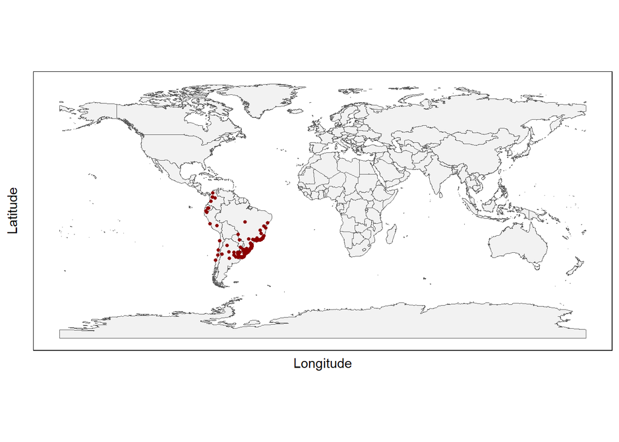

```r
o.mon.SouthAmerica = o.mon %>%
  dplyr::filter(lon >= -82 & lon <= -34,
    lat >= -56 & lat <= 13)

ggplot() +
  # Add raster layer of world map
  geom_sf(data = world_map, alpha = 0.5) +
  # Add GPS points
  geom_point(
    data = o.mon.SouthAmerica,
    size = 1, colour = "darkred",
    aes(x = lon, y = lat)
  )  +
  xlab("Longitude") +
  ylab("Latitude")
```

Let’s get a raster map of Cameroon, at the 2.5 arc-min resolution:

```r
# read in 2.5 res
pred_clim_2.5 = terra::rast( list.files(
  here::here("data/environmental_layers/current/wc2.1_2.5m/") ,
  full.names = TRUE,
  pattern = '.tif'
))

# set the CRS (coordinate reference system) projection for the current climate layers
terra::crs(pred_clim_2.5) = "epsg:4326"
terra::crs(pred_clim_2.5, describe = T)
```

```
##     name authority code  area             extent
## 1 WGS 84      EPSG 4326 World -180, 180, 90, -90
```

```r
cameroon_ext = rnaturalearth::ne_countries(scale = "medium", returnclass = "sf") %>%
                  dplyr::filter(name %in% c("Cameroon"))

# get all the bioclim rasters for Cameroon
cam = terra::crop(pred_clim_2.5, cameroon_ext)

cam = terra::mask(cam, cameroon_ext)
# check how many grid cells we have for Cameroon -> this is the number of data points we have available for each climate variable (assuming no NAs, which are a posibility)
terra::ncell(cam)
```

```
## [1] 50142
```

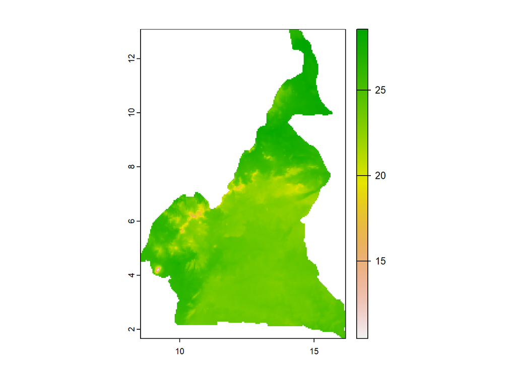

```r
# plot annual average temp
terra::plot(cam$wc2.1_2.5m_bio_1)
```

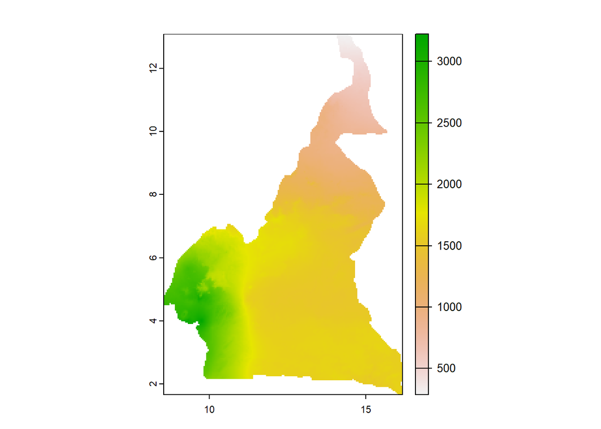

```r
# plot annual average precip
terra::plot(cam$wc2.1_2.5m_bio_12)
```

Now, we need to extract the climate data (here we’ll focus on just temperature and precipitation) from each GPS point in South America. Then, we need temperature and precipitation data from Cameroon. We could either generate random points in the country and extract from those, or we could extract the value at each grid cell in the country. This means that we could extract a maximum of `terra::ncell(cam)`, which was 50,142 data points. We’ll likely end up with a lot less than that due to missing data.

First, let’s get our climate data from South America:

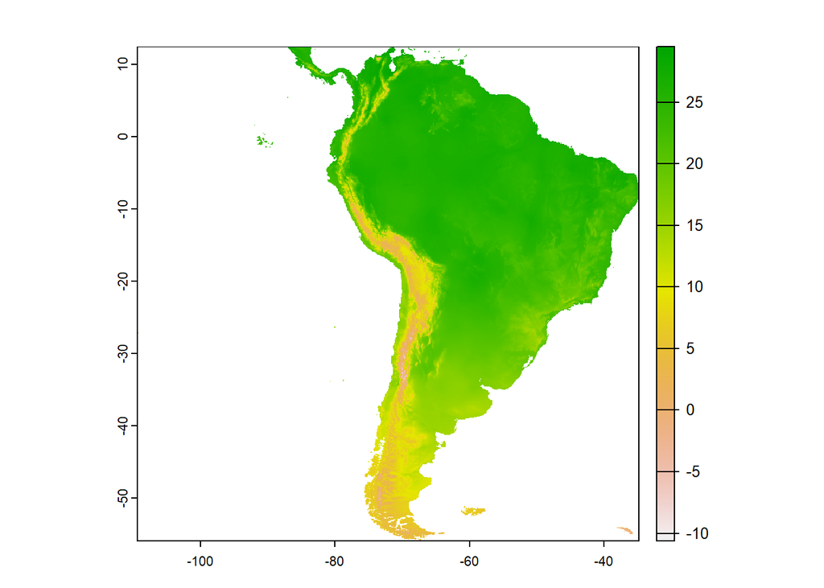

```r
# pull out our lat and lon points
o.mon.SouthAmerica.GPS = o.mon.SouthAmerica %>%
  dplyr::select(lon, lat)

# get the raster for the South American continent
southAmerica_ext = rnaturalearth::ne_countries(scale = "medium",
                                           returnclass = "sf") %>%
  dplyr::filter(continent %in% c("South America"))
# set the CRS
southAmerica_ext = sf::st_set_crs(southAmerica_ext, 4326)

# Mask reduced set of WORLDCLIM layers to the extent of South America
southAmerica = raster::crop(pred_clim_2.5, southAmerica_ext)

# keep just bio1 and bio12
southAmerica_bio1_bio12 = southAmerica[[c("wc2.1_2.5m_bio_1", "wc2.1_2.5m_bio_12")]]

# plot temp
terra::plot(southAmerica_bio1_bio12$wc2.1_2.5m_bio_1)
```

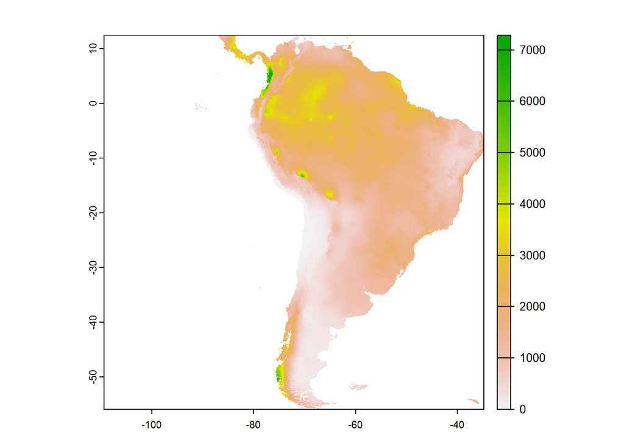

```r
# plot precip
terra::plot(southAmerica_bio1_bio12$wc2.1_2.5m_bio_12)
```

```r
# extract the temperature and precip data at the specified GPS points
clim_SouthAmerica = base::data.frame( raster::extract(southAmerica_bio1_bio12,
                cbind(o.mon.SouthAmerica$lon, o.mon.SouthAmerica$lat)) )

# add the lat and lon columns to the data
clim_SouthAmerica = cbind(o.mon.SouthAmerica.GPS, clim_SouthAmerica)
```

Now we can get all the climate values at each grid cell in Cameroon (remember, there are no recorded localities for our cactus in Cameroon. We just want to get the climate data from the overall landscape so that we can compare the South American climate where we know the cactus occurs to that of Cameroon):

```r
# extract the bio1 and bio12 data from each grid cell of Cameroon
clim_cameroon = cam[[c("wc2.1_2.5m_bio_1", "wc2.1_2.5m_bio_12")]] %>%
 terra::as.data.frame(xy = TRUE) %>%
 dplyr::rename(lon = x, lat = y)

head(clim_cameroon)
```

```
##          lon     lat wc2.1_2.5m_bio_1 wc2.1_2.5m_bio_12
## 133 14.06250 13.0625         26.51367               304
## 134 14.10417 13.0625         26.50617               301
## 135 14.14583 13.0625         26.52583               299
## 136 14.18750 13.0625         26.48417               299
## 137 14.22917 13.0625         26.45833               297
## 138 14.27083 13.0625         26.52450               295
```

```r
nrow(clim_cameroon)
```

```
## [1] 22394
```

🟢 **Now over to you**

- Combine the two data frames into one, where you add a grouping column for region (i.e. “South America” and “Cameroon”). You can use `dplyr::bind_rows())` to do this, where you add `.id = "region"`
- Run a t-test to compare temperature (bio1) and precipitation (bio12) between the climates of South America and Cameroon. Is there a significant difference?
- Create a ridgeline and boxplot for temperature and precipitation for both South America and Cameroon
- If we trained an SDM on the South American points and projected it onto Cameroon, how transferable do you think the model will be (assuming we used just temperature and precipitation) as predictor variables?

You should be able to produce these plots:

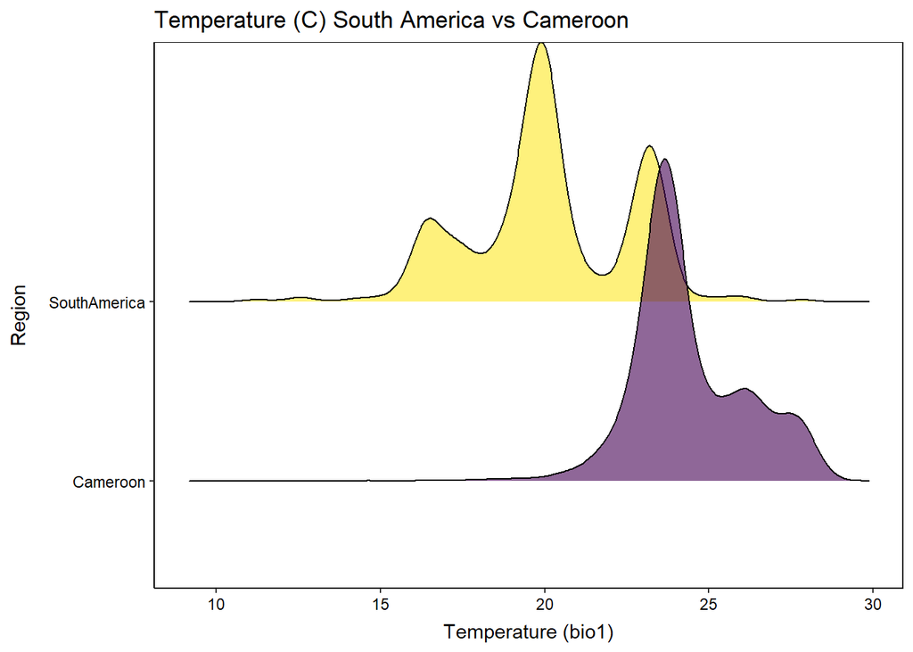

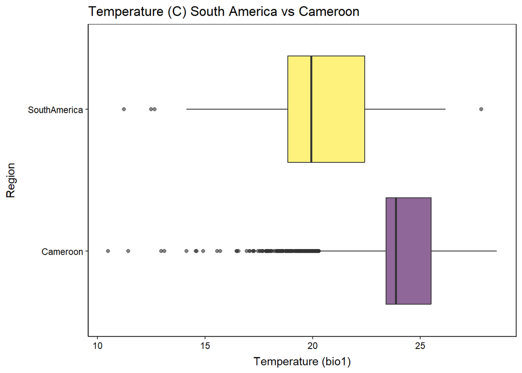

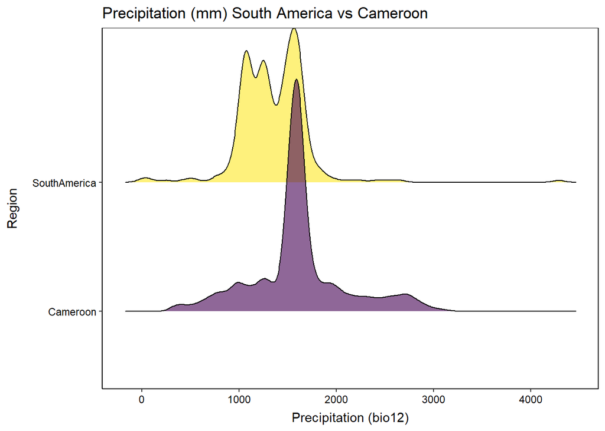

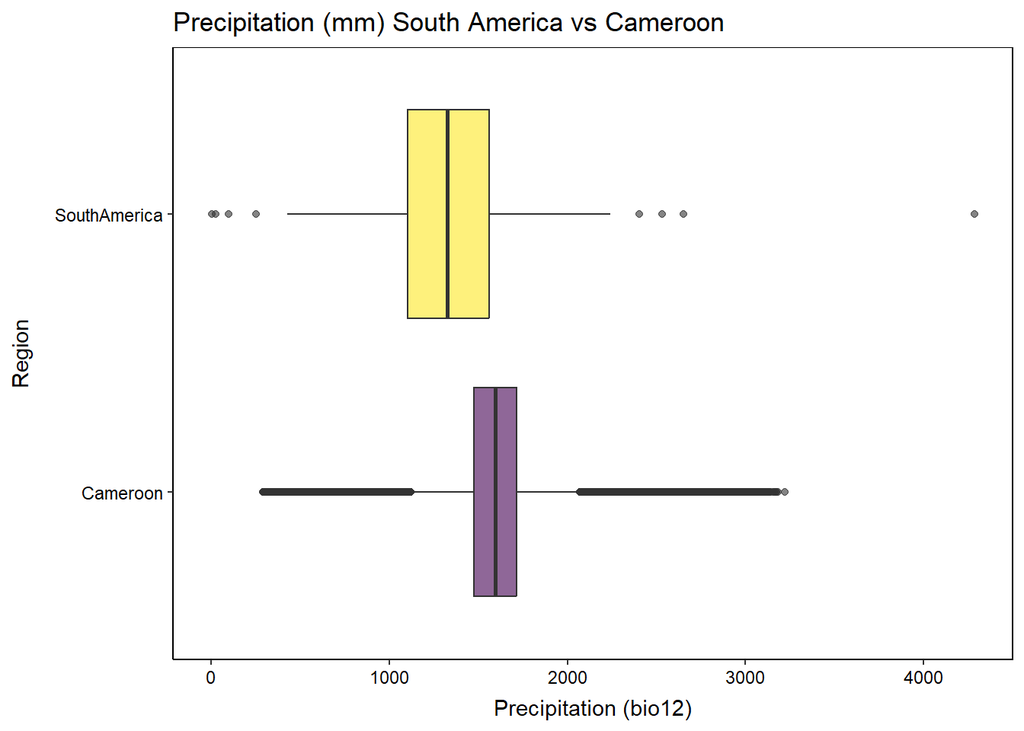

### Exercise 5: future climates

In this activity, we’ll look at raster layers for a future climate scenario. There are multiple rasters available online for different levels of climate change severity. Here, we’ll look at a potential future climate for the year 2070 under the worst possible climate scenario (RCP8.5). This assumes that greenhouse gas emissions will continue at a rapid rate. To download the data, you can use the code in the block below.

```r
# Download the RCP4.5 layers for 2050 to PC
  Env2070_8.5 = geodata::cmip6_world(
  ssp = "585",
  time = "2061-2080",
  model = "AWI-CM-1-1-MR",
  var = "bioc",
  res = 2.5,
  path = here::here("data/environmental_layers/2070")
)
```

Let’s have a look at how temperature and precipitation is predicted to change from the current climate to that expected by 2070 under the RCP8.5 scenario.

This code gets a map of South Africa:

```r
southafrica_ext = rnaturalearth::ne_countries(scale = "medium", returnclass = "sf") %>%
                  dplyr::filter(name %in% c("South Africa"))

# convert the SA raster map into a SpatVector object
southafrica_vect = terra::vect(southafrica_ext)
# define the extent of South Africa, excluding Marion Island
country_ext = ext(16, 33, -35, -22)
# crop the SA SpatVector accordingly
southafrica_vect = terra::crop(southafrica_vect, country_ext)
```

Here we read in our climate raster layers for the current climate:

```r
# current climate
pred_clim_2.5 = terra::rast( list.files(
  here::here("data/environmental_layers/current/wc2.1_2.5m/") ,
  full.names = TRUE,
  pattern = '.tif'
))

# set the CRS (coordinate reference system) projection for the current climate layers
terra::crs(pred_clim_2.5) = "epsg:4326"
terra::crs(pred_clim_2.5, describe = T)
```

```
##     name authority code  area             extent
## 1 WGS 84      EPSG 4326 World -180, 180, 90, -90
```

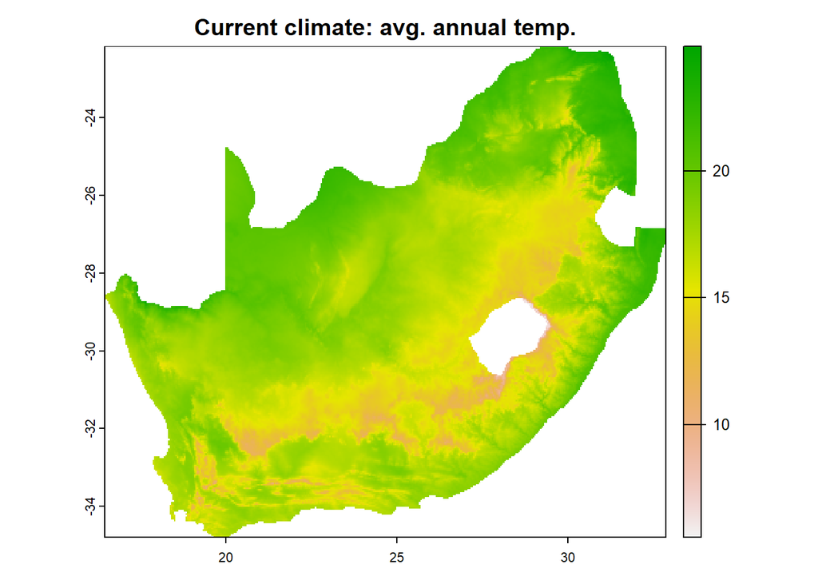

```r
# get all the current bioclim rasters for SA
sa.current = terra::crop(pred_clim_2.5, southafrica_vect)
sa.current = terra::mask(sa.current, southafrica_vect)

terra::plot(sa.current$wc2.1_2.5m_bio_1, main = "Current climate: avg. annual temp.")
```

Here we read in our raster layers for the future climate (2070):

```r
# future climate
Env2070_8.5 = terra::rast( list.files(
  here::here("data/environmental_layers/2070_cmip6/RCP8.5/wc2.1_2.5m") ,
  full.names = TRUE,
  pattern = '.tif'
))

terra::crs(Env2070_8.5) = "epsg:4326"
terra::crs(Env2070_8.5, describe = T)
```

```
##     name authority code  area             extent
## 1 WGS 84      EPSG 4326 World -180, 180, 90, -90
```

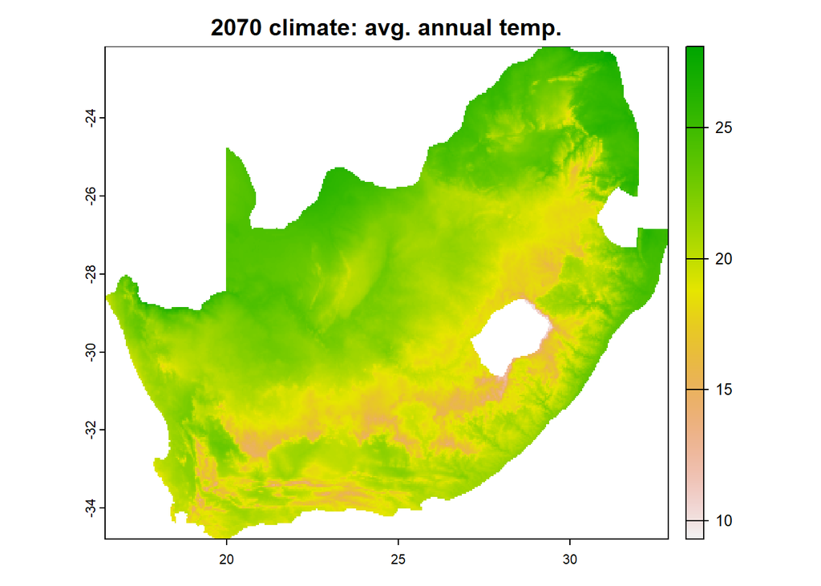

```r
# get all the future bioclim rasters for SA
sa.future = terra::crop(Env2070_8.5, southafrica_vect)
sa.future = terra::mask(sa.future, southafrica_vect)

terra::plot(sa.future$`wc2.1_2.5m_bioc_AWI-CM-1-1-MR_ssp585_2061-2080_1`, main = "2070 climate: avg. annual temp.")
```

🟢 **Your tasks are to:**

- Get the difference between (1) the temperature (**bio1**) and (2) precipitation (**bio12**) layers in the current and future climate rasters. For example: `future$bio1 - current$bio1` and `future$bio12 - current$bio12`
- Plot the two difference rasters
- Threshold each difference raster so that you plot maps of South Africa showing the:
  - Temperature difference `> 3.5` degrees C by the year 2070
  - Precipitation difference `< -50` mm by the year 2070 (i.e. a decrease in precipitation by more than 50 mm)
- Which parts of South Africa appear to be most vulnerable to higher temperatures and lower rainfall in the future?

Your maps should look similar to these:

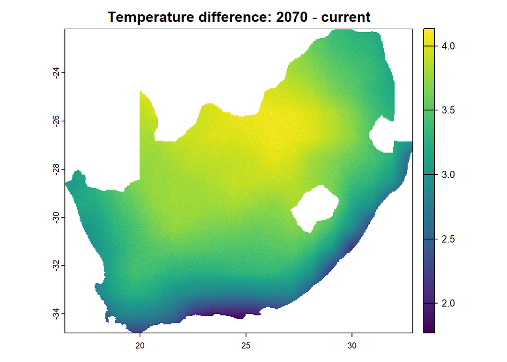

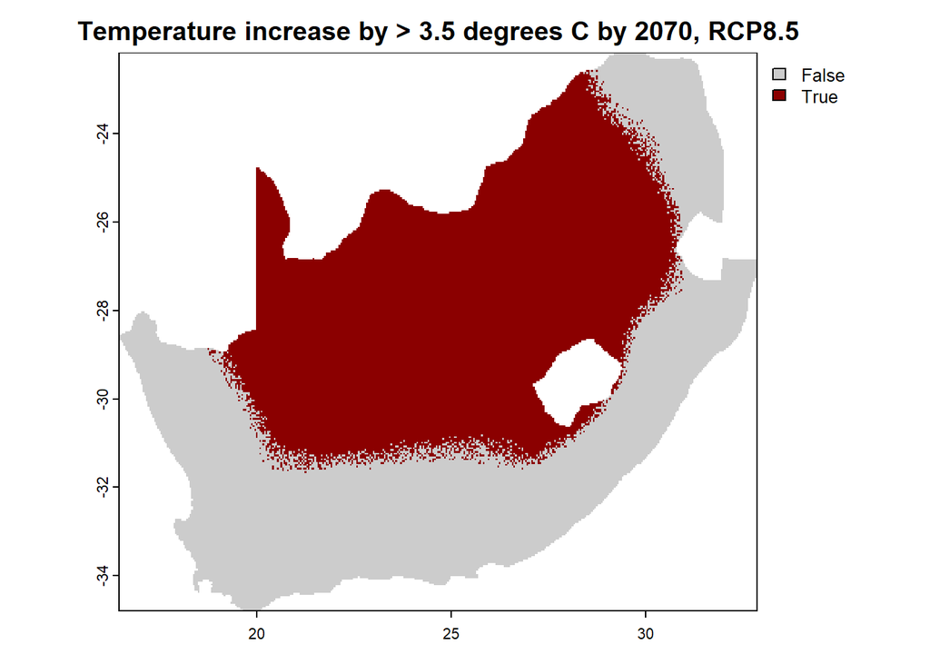

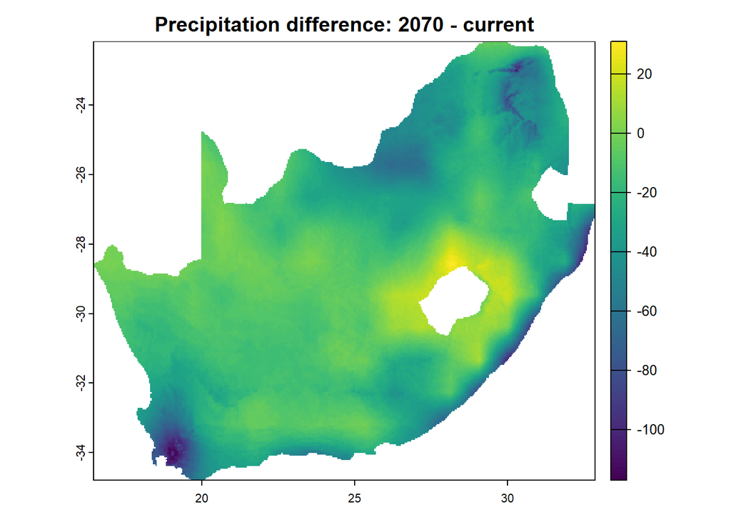

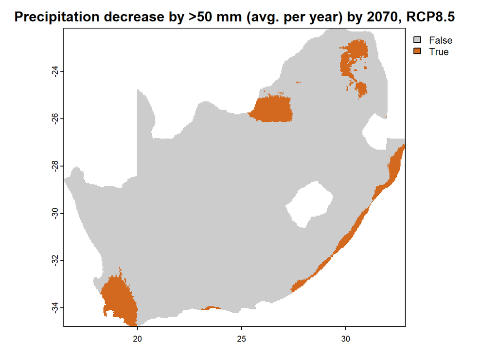